# Assignment2

2026-04-19

# Introduction

In this study, Support Vector Machines (SVMs) are used to classify whether an individual has been diagnosed with diabetes based on a set of demographic and behavioral variables using data from the National Health Interview Survey (NHIS).

# Variables

From codebook:

- Demographics: AGE, SEX, EDUC, POVERTY
- Health outcomes (targets):
  - CANCEREV
  - CHEARTDIEV
  - DIABETICEV
  - HEARTATTEV
  - STROKEV
- Behavior variables:
  - Exercise: MOD10DMIN, VIG10DMIN
  - Diet: FRUTNO, VEGENO, PIZZANO, SODAPNO
  - Sleep: HRSLEEP
  - Smoking: CIGDAYMO

Model to predict diabetes (DIABETICEV) because it is a common disease and has a strong relationship with lifestyle.

# Theoretical Background

A Support Vector Machine (SVM) is a supervised learning method used for classification that identifies an optimal boundary (hyperplane) that separates classes. The objective is to maximize the margin between classes while allowing for some misclassification.

The parameter C controls the tradeoff between maximizing the margin and minimizing classification error. Larger values of C penalize misclassification more heavily. SVMs can also incorporate kernel functions to model nonlinear relationships. The linear kernel produces a straight decision boundary, the polynomial kernel allows for curved boundaries controlled by the degree parameter, and the radial (RBF) kernel provides a flexible nonlinear boundary controlled by the gamma parameter. These kernels enable SVMs to capture varying levels of complexity in the data.

# Data Cleaning

```r
library(tidyverse)
library(caret)
library(e1071)
# Load data
df <- read.csv("~/DATA 5322 02 Statistical Machine Learning 2/Data/nhis_2022.csv")

invalid_codes <- c(7, 8, 9, 97, 98, 99, 997, 998, 999)

df_clean <- df %>%
  select(DIABETICEV, AGE, BMICALC, HRSLEEP, MOD10DMIN, SODAPNO) %>%

  # Replace invalid codes with NA
  mutate(across(everything(), ~ ifelse(. %in% invalid_codes, NA, .))) %>%

  # Keep valid diabetes responses and filter people who's hours of sleep are less than 15
  filter(DIABETICEV %in% c(1, 2)) %>%
  filter(HRSLEEP <= 15) %>%

  # Recode outcome
  mutate(
    diabetes = factor(ifelse(DIABETICEV == 2, "Yes", "No"))
  ) %>%
  # remove bad bmi
  mutate(BMICALC = ifelse(BMICALC > 100, NA, BMICALC)) %>%
  select(-DIABETICEV) %>%
  na.omit()
```

Target Variable: DIABETICEV Definition:“Ever told had diabetes” 1 = No 2 = Yes

Demographic Variables - AGE: Respondent’s age in years - BMICALC: Body Mass Index (BMI) calculated from height and weight - HRSLEEP: Average hours of sleep per day - MOD10DMIN: Minutes of moderate physical activity (in sessions of at least 10 minutes) - SODAPNO: Frequency of soft drink (soda) consumption

# Train/Test Split

```r
set.seed(123)

train_index <- createDataPartition(df_clean$diabetes, p = 0.7, list = FALSE)

train <- df_clean[train_index, ]
test  <- df_clean[-train_index, ]
```

Split 70/30 into testing and training data.

# Balance Data and Scale Data

```r
# balance training data only so that we don't overpredict based on the data imbalance
train_balanced <- train %>%
  group_by(diabetes) %>%
  sample_n(min(table(train$diabetes))) %>%
  ungroup()
```

```r
preproc <- preProcess(train, method = c("center", "scale"))

train_scaled <- predict(preproc, train_balanced)
test_scaled  <- predict(preproc, test)
```

The training data were balanced using downsampling to address class imbalance and prevent the model from overpredicting the majority class. Predictor variables were then standardized using centering and scaling to ensure all features contributed equally to the SVM models.

# Create Plots

## Boxplots

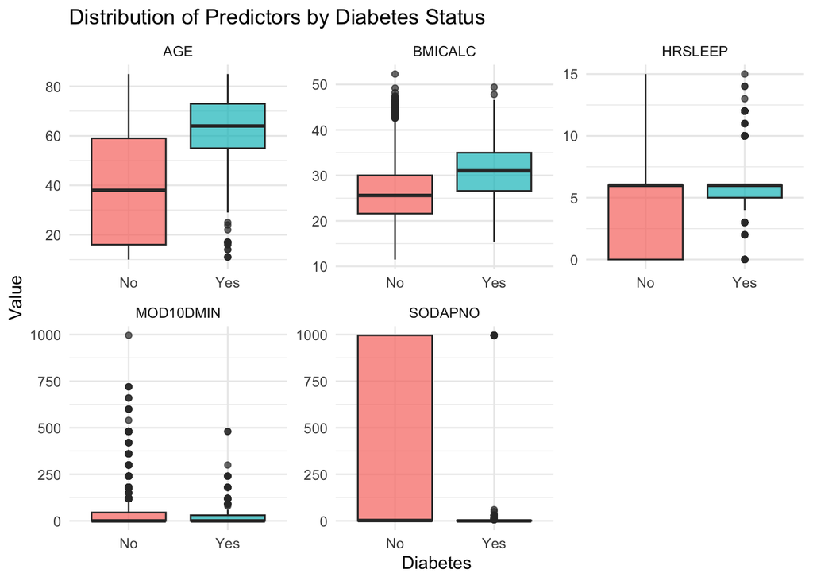

```r
library(tidyr)
library(ggplot2)

long_data <- train %>%
  pivot_longer(
    cols = c(AGE, BMICALC, HRSLEEP, MOD10DMIN, SODAPNO),
    names_to = "Variable",
    values_to = "Value"
  )

ggplot(long_data, aes(x = diabetes, y = Value, fill = diabetes)) +
  geom_boxplot(alpha = 0.7) +
  facet_wrap(~ Variable, scales = "free") +
  theme_minimal() +
  labs(
    title = "Distribution of Predictors by Diabetes Status",
    x = "Diabetes",
    y = "Value"
  ) +
  theme(legend.position = "none")
```

[figure not shown]

```r
ggplot(train, aes(x = MOD10DMIN, y = diabetes, color = diabetes)) +
  geom_jitter(height = 0.15, alpha = 0.5) +
  labs(
    title = "BMI Distribution by Diabetes Status",
    x = "BMI",
    y = "Diabetes"
  ) +
  theme_minimal()
```

## SVM Plots

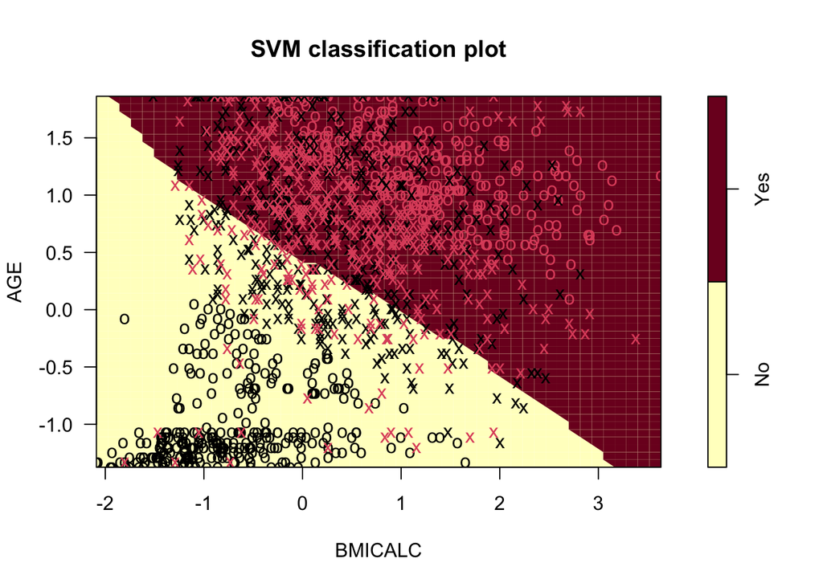

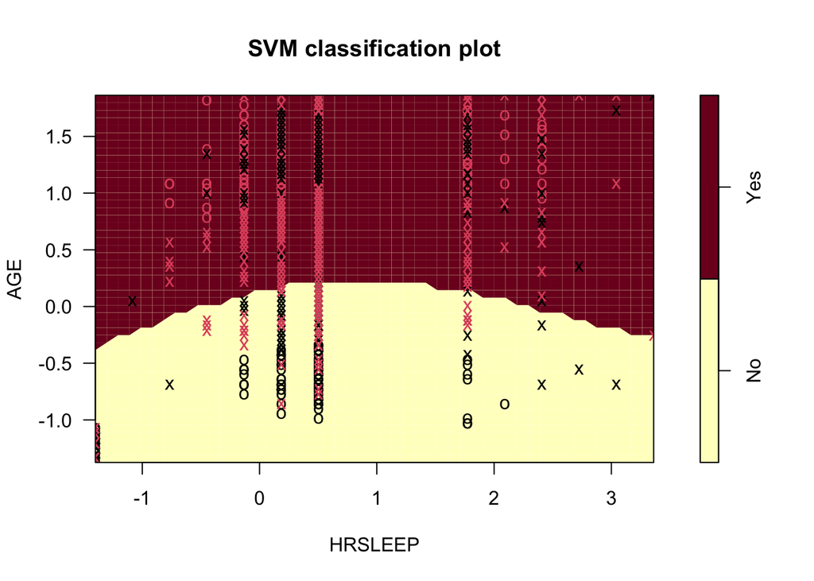

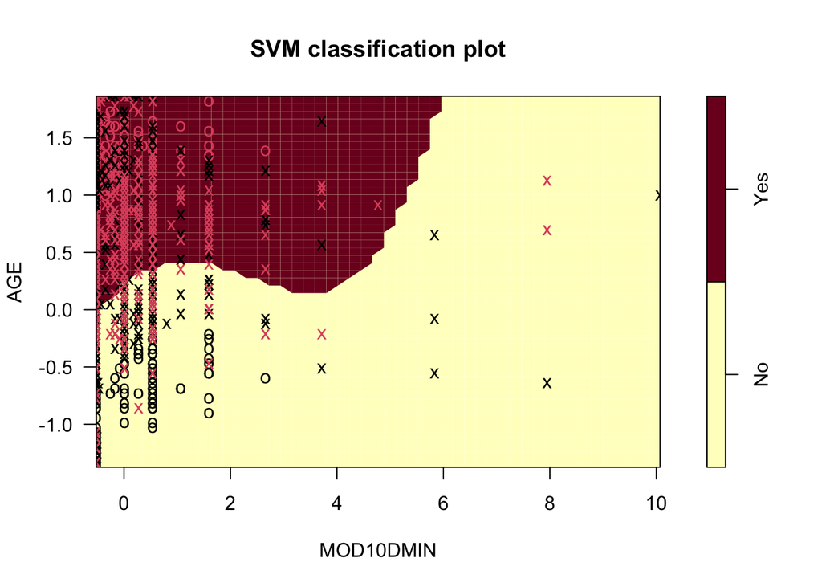

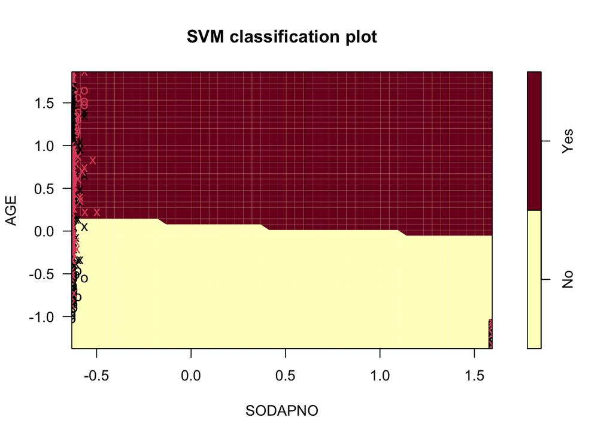

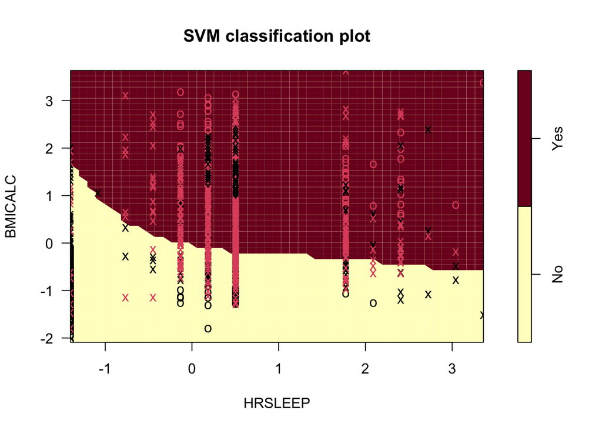

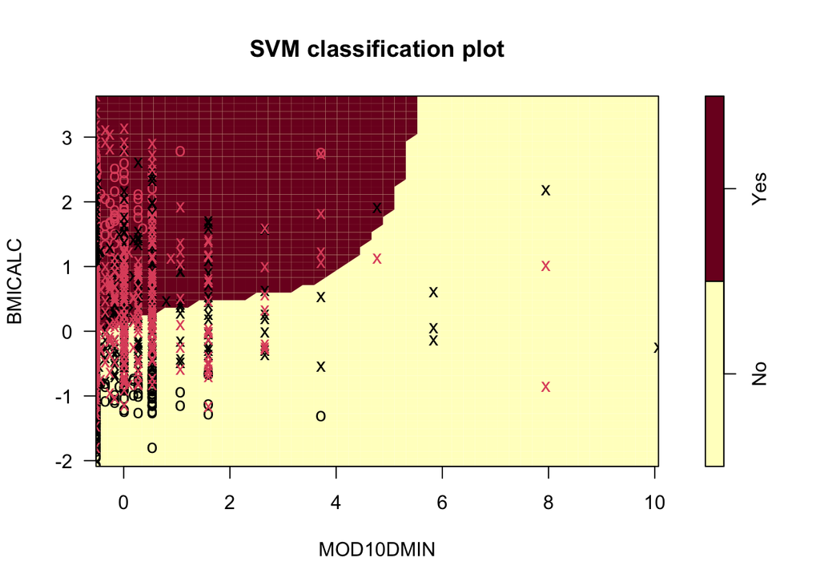

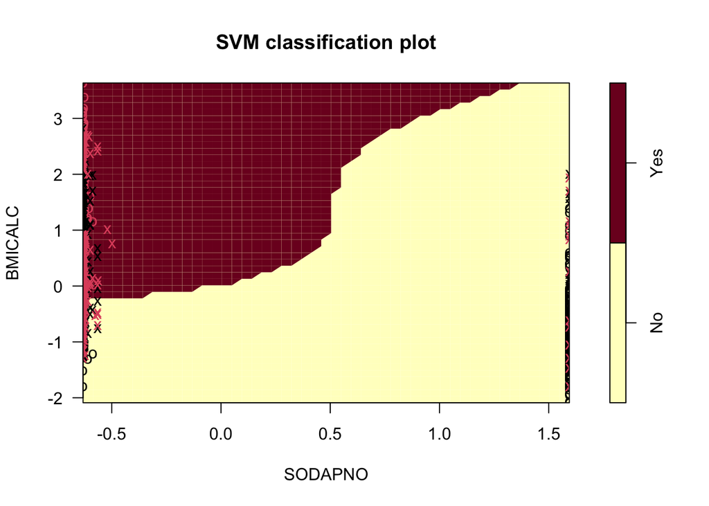

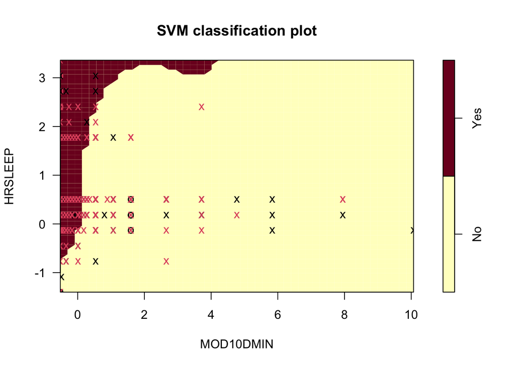

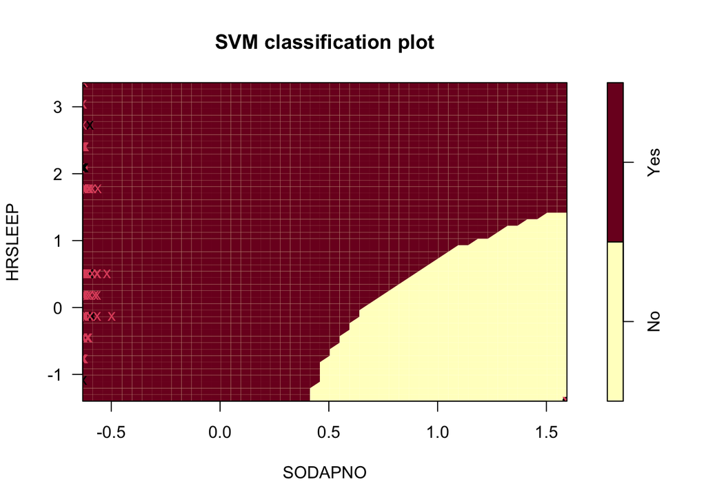

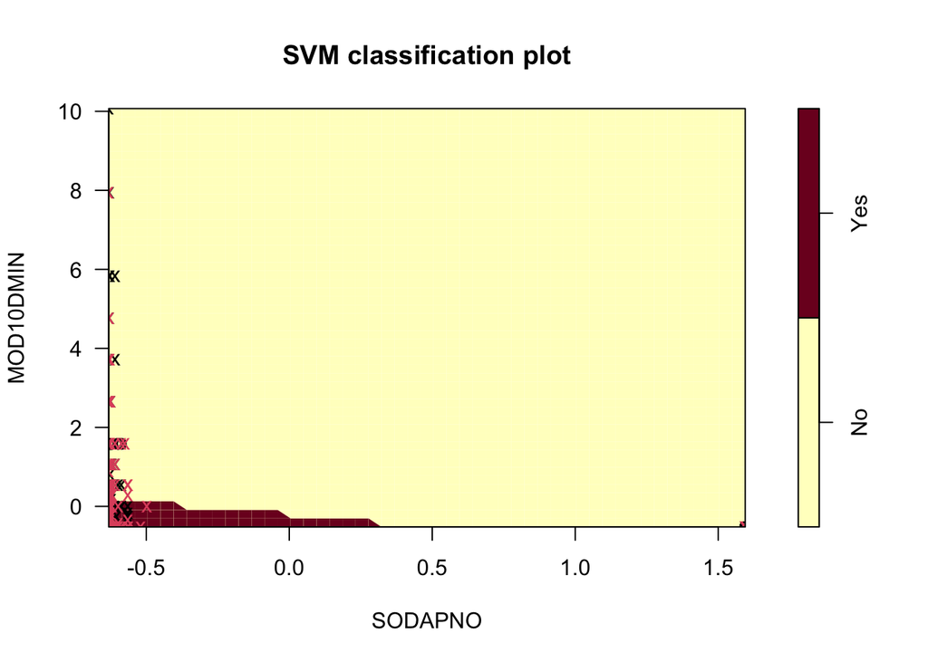

```r
# choose the 5 variables you want to visualize
vars <- c("AGE", "BMICALC", "HRSLEEP", "MOD10DMIN", "SODAPNO")

# create all 2-variable combinations
var_pairs <- combn(vars, 2, simplify = FALSE)

# set plotting layout: adjust depending on how many plots you want per page
par(mfrow = c(2, 2))

for (pair in var_pairs) {

  # subset to response + chosen pair
  plot_data <- train_scaled[, c("diabetes", pair)]

  # fit a 2-variable radial SVM
  svm_plot <- svm(
    diabetes ~ .,
    data = plot_data,
    kernel = "radial",
    gamma = 0.1,
    cost = 1,
    scale = FALSE
  )

  # plot with a custom title
  plot(
    svm_plot,
    plot_data,
    main = paste("Radial SVM:", pair[1], "vs", pair[2])
  )
}
```

The boundaries show some nonlinear structure, particularly for BMI and physical activity, but there remains significant overlap between classes. This explains why more flexible kernels provide only marginal improvements in predictive performance.

# Train 3 SVM Models:

## Linear

```r
library(e1071)

set.seed(1)

linear_tune <- tune(
  svm,
  diabetes ~ .,
  data = train_scaled,
  kernel = "linear",
  ranges = list(
    cost = c(0.01, 0.1, 1, 5, 10)
  )
)

summary(linear_tune)
```

```
##
## Parameter tuning of 'svm':
##
## - sampling method: 10-fold cross validation
##
## - best parameters:
##  cost
##     1
##
## - best performance: 0.2419118
##
## - Detailed performance results:
##    cost     error dispersion
## 1  0.01 0.2544118 0.04535307
## 2  0.10 0.2448529 0.04412445
## 3  1.00 0.2419118 0.04180341
## 4  5.00 0.2419118 0.04180341
## 5 10.00 0.2419118 0.04180341
```

Lowest=0.2419 - cost = 1

```r
linear_best <- linear_tune$best.model
pred_linear_tuned <- predict(linear_best, newdata = test_scaled)

confusionMatrix(pred_linear_tuned, test_scaled$diabetes)
```

```
## Confusion Matrix and Statistics
##
##           Reference
## Prediction   No  Yes
##        No  1954   47
##        Yes  985  244
##
##                Accuracy : 0.6805
##                  95% CI : (0.6641, 0.6966)
##     No Information Rate : 0.9099
##     P-Value [Acc > NIR] : 1
##
##                   Kappa : 0.2053
##
##  Mcnemar's Test P-Value : <2e-16
##
##             Sensitivity : 0.6649
##             Specificity : 0.8385
##          Pos Pred Value : 0.9765
##          Neg Pred Value : 0.1985
##              Prevalence : 0.9099
##          Detection Rate : 0.6050
##    Detection Prevalence : 0.6195
##       Balanced Accuracy : 0.7517
##
##        'Positive' Class : No
##
```

The linear SVM model uses a straight decision boundary to separate the two classes. The model was tuned using cross-validation, and the optimal parameter was cost (C) = 1. The tuned linear model achieved an accuracy of 68.1%, a balanced accuracy of 0.7517, and a kappa of 0.2053. These results indicate that a simple linear boundary is sufficient to capture much of the structure in the data.

## Polynomial

```r
set.seed(1)

poly_tune <- tune(
  svm,
  diabetes ~ .,
  data = train_scaled,
  kernel = "polynomial",
  ranges = list(
    cost = c(0.01, 0.1, 1, 5, 10),
    degree = c(2, 3, 4)
  )
)

summary(poly_tune)
```

```
##
## Parameter tuning of 'svm':
##
## - sampling method: 10-fold cross validation
##
## - best parameters:
##  cost degree
##     5      2
##
## - best performance: 0.2573529
##
## - Detailed performance results:
##     cost degree     error dispersion
## 1   0.01      2 0.3647059 0.03831691
## 2   0.10      2 0.3566176 0.03986141
## 3   1.00      2 0.2691176 0.03434872
## 4   5.00      2 0.2573529 0.03668292
## 5  10.00      2 0.2573529 0.03517819
## 6   0.01      3 0.3602941 0.03997428
## 7   0.10      3 0.3477941 0.04188954
## 8   1.00      3 0.3014706 0.04676173
## 9   5.00      3 0.2860294 0.04604322
## 10 10.00      3 0.2779412 0.03994421
## 11  0.01      4 0.3617647 0.04083660
## 12  0.10      4 0.3536765 0.03756482
## 13  1.00      4 0.3198529 0.03863697
## 14  5.00      4 0.3058824 0.04045232
## 15 10.00      4 0.3000000 0.04270618
```

Lowest = 0.257: - cost=5 or 10 - degree=2

```r
poly_best <- poly_tune$best.model
pred_poly_tuned <- predict(poly_best, newdata = test_scaled)

confusionMatrix(pred_poly_tuned, test_scaled$diabetes)
```

```
## Confusion Matrix and Statistics
##
##           Reference
## Prediction   No  Yes
##        No  1691   25
##        Yes 1248  266
##
##                Accuracy : 0.6059
##                  95% CI : (0.5888, 0.6228)
##     No Information Rate : 0.9099
##     P-Value [Acc > NIR] : 1
##
##                   Kappa : 0.1692
##
##  Mcnemar's Test P-Value : <2e-16
##
##             Sensitivity : 0.5754
##             Specificity : 0.9141
##          Pos Pred Value : 0.9854
##          Neg Pred Value : 0.1757
##              Prevalence : 0.9099
##          Detection Rate : 0.5235
##    Detection Prevalence : 0.5313
##       Balanced Accuracy : 0.7447
##
##        'Positive' Class : No
##
```

The polynomial SVM allows for curved decision boundaries, controlled by the degree parameter. Tuning identified the optimal parameters as cost = 5 (or 10) and degree = 2. The tuned polynomial model achieved an accuracy of 60.6%, a balanced accuracy of 0.7447, and a kappa of 0.1692. Despite increased flexibility, the model did not improve performance compared to the linear model, suggesting limited nonlinear structure in the data.

## Radial

```r
set.seed(1)

radial_tune <- tune(
  svm,
  diabetes ~ .,
  data = train_scaled,
  kernel = "radial",
  ranges = list(
    cost = c(0.01, 0.1, 1, 5, 10),
    gamma = c(0.01, 0.1, 1)
  )
)

summary(radial_tune)
```

```
##
## Parameter tuning of 'svm':
##
## - sampling method: 10-fold cross validation
##
## - best parameters:
##  cost gamma
##     1     1
##
## - best performance: 0.2360294
##
## - Detailed performance results:
##     cost gamma     error dispersion
## 1   0.01  0.01 0.5205882 0.03681369
## 2   0.10  0.01 0.2926471 0.04170990
## 3   1.00  0.01 0.2492647 0.04223232
## 4   5.00  0.01 0.2463235 0.03894669
## 5  10.00  0.01 0.2477941 0.03998179
## 6   0.01  0.10 0.3051471 0.04509404
## 7   0.10  0.10 0.2536765 0.04318875
## 8   1.00  0.10 0.2485294 0.04673603
## 9   5.00  0.10 0.2477941 0.04160174
## 10 10.00  0.10 0.2463235 0.04248759
## 11  0.01  1.00 0.2838235 0.03417338
## 12  0.10  1.00 0.2433824 0.04034078
## 13  1.00  1.00 0.2360294 0.03897752
## 14  5.00  1.00 0.2455882 0.03909295
## 15 10.00  1.00 0.2551471 0.04217538
```

```r
radial_best <- radial_tune$best.model
pred_radial_tuned <- predict(radial_best, newdata = test_scaled)

confusionMatrix(pred_radial_tuned, test_scaled$diabetes)
```

```
## Confusion Matrix and Statistics
##
##           Reference
## Prediction   No  Yes
##        No  1914   41
##        Yes 1025  250
##
##                Accuracy : 0.67
##                  95% CI : (0.6534, 0.6862)
##     No Information Rate : 0.9099
##     P-Value [Acc > NIR] : 1
##
##                   Kappa : 0.2023
##
##  Mcnemar's Test P-Value : <2e-16
##
##             Sensitivity : 0.6512
##             Specificity : 0.8591
##          Pos Pred Value : 0.9790
##          Neg Pred Value : 0.1961
##              Prevalence : 0.9099
##          Detection Rate : 0.5926
##    Detection Prevalence : 0.6053
##       Balanced Accuracy : 0.7552
##
##        'Positive' Class : No
##
```

## Results: Model Evaluation and Comparison

```r
## Model Evaluation

pred_linear <- predict(linear_best, newdata = test_scaled)
pred_poly   <- predict(poly_best, newdata = test_scaled)
pred_radial <- predict(radial_best, newdata = test_scaled)

cm_linear <- confusionMatrix(pred_linear, test_scaled$diabetes)
cm_poly   <- confusionMatrix(pred_poly, test_scaled$diabetes)
cm_radial <- confusionMatrix(pred_radial, test_scaled$diabetes)

cat("SVM Linear: \n")
```

```
## SVM Linear:
```

```r
cm_linear
```

```
## Confusion Matrix and Statistics
##
##           Reference
## Prediction   No  Yes
##        No  1954   47
##        Yes  985  244
##
##                Accuracy : 0.6805
##                  95% CI : (0.6641, 0.6966)
##     No Information Rate : 0.9099
##     P-Value [Acc > NIR] : 1
##
##                   Kappa : 0.2053
##
##  Mcnemar's Test P-Value : <2e-16
##
##             Sensitivity : 0.6649
##             Specificity : 0.8385
##          Pos Pred Value : 0.9765
##          Neg Pred Value : 0.1985
##              Prevalence : 0.9099
##          Detection Rate : 0.6050
##    Detection Prevalence : 0.6195
##       Balanced Accuracy : 0.7517
##
##        'Positive' Class : No
##
```

```r
cat("\nSVM Polynomial: \n")
```

```
##
## SVM Polynomial:
```

```r
cm_poly
```

```
## Confusion Matrix and Statistics
##
##           Reference
## Prediction   No  Yes
##        No  1691   25
##        Yes 1248  266
##
##                Accuracy : 0.6059
##                  95% CI : (0.5888, 0.6228)
##     No Information Rate : 0.9099
##     P-Value [Acc > NIR] : 1
##
##                   Kappa : 0.1692
##
##  Mcnemar's Test P-Value : <2e-16
##
##             Sensitivity : 0.5754
##             Specificity : 0.9141
##          Pos Pred Value : 0.9854
##          Neg Pred Value : 0.1757
##              Prevalence : 0.9099
##          Detection Rate : 0.5235
##    Detection Prevalence : 0.5313
##       Balanced Accuracy : 0.7447
##
##        'Positive' Class : No
##
```

```r
cat("\nSVM Radial: \n")
```

```
##
## SVM Radial:
```

```r
cm_radial
```

```
## Confusion Matrix and Statistics
##
##           Reference
## Prediction   No  Yes
##        No  1914   41
##        Yes 1025  250
##
##                Accuracy : 0.67
##                  95% CI : (0.6534, 0.6862)
##     No Information Rate : 0.9099
##     P-Value [Acc > NIR] : 1
##
##                   Kappa : 0.2023
##
##  Mcnemar's Test P-Value : <2e-16
##
##             Sensitivity : 0.6512
##             Specificity : 0.8591
##          Pos Pred Value : 0.9790
##          Neg Pred Value : 0.1961
##              Prevalence : 0.9099
##          Detection Rate : 0.5926
##    Detection Prevalence : 0.6053
##       Balanced Accuracy : 0.7552
##
##        'Positive' Class : No
##
```

Model performance was evaluated using a held-out test dataset and confusion matrices. Key metrics included accuracy, balanced accuracy, sensitivity, specificity, and Cohen’s kappa. Because the dataset is imbalanced, balanced accuracy was emphasized as a more appropriate measure of performance across both classes. The tuned linear SVM achieved an accuracy of 68.1%, a balanced accuracy of 0.7517, and a kappa of 0.2053. The polynomial SVM performed worse, with an accuracy of 60.6%, a balanced accuracy of 0.7447, and a kappa of 0.1692. The radial SVM achieved the best performance, with an accuracy of 67.0%, a balanced accuracy of 0.7552, and a kappa of 0.2023.

# Appendix: Tables and Charts for Poster

## Compare Models

```r
library(caret)
library(dplyr)

## Compare Models

library(caret)
library(dplyr)
library(knitr)

model_table <- data.frame(
  Model = c("Linear", "Polynomial", "Radial"),
  Accuracy = c(
    cm_linear$overall["Accuracy"],
    cm_poly$overall["Accuracy"],
    cm_radial$overall["Accuracy"]
  ),
  Balanced_Accuracy = c(
    cm_linear$byClass["Balanced Accuracy"],
    cm_poly$byClass["Balanced Accuracy"],
    cm_radial$byClass["Balanced Accuracy"]
  ),
  Kappa = c(
    cm_linear$overall["Kappa"],
    cm_poly$overall["Kappa"],
    cm_radial$overall["Kappa"]
  ),
  Sensitivity = c(
    cm_linear$byClass["Sensitivity"],
    cm_poly$byClass["Sensitivity"],
    cm_radial$byClass["Sensitivity"]
  ),
  Specificity = c(
    cm_linear$byClass["Specificity"],
    cm_poly$byClass["Specificity"],
    cm_radial$byClass["Specificity"]
  )
) %>%
  mutate(across(where(is.numeric), ~ round(., 4)))

model_table
```

```
##        Model Accuracy Balanced_Accuracy  Kappa Sensitivity Specificity
## 1     Linear   0.6805            0.7517 0.2053      0.6649      0.8385
## 2 Polynomial   0.6059            0.7447 0.1692      0.5754      0.9141
## 3     Radial   0.6700            0.7552 0.2023      0.6512      0.8591
```

```r
kable(model_table, caption = "Comparison of Tuned SVM Models")
```

Comparison of Tuned SVM Models

| Model | Accuracy | Balanced_Accuracy | Kappa | Sensitivity | Specificity |
| --- | --- | --- | --- | --- | --- |
| Linear | 0.6805 | 0.7517 | 0.2053 | 0.6649 | 0.8385 |
| Polynomial | 0.6059 | 0.7447 | 0.1692 | 0.5754 | 0.9141 |
| Radial | 0.6700 | 0.7552 | 0.2023 | 0.6512 | 0.8591 |

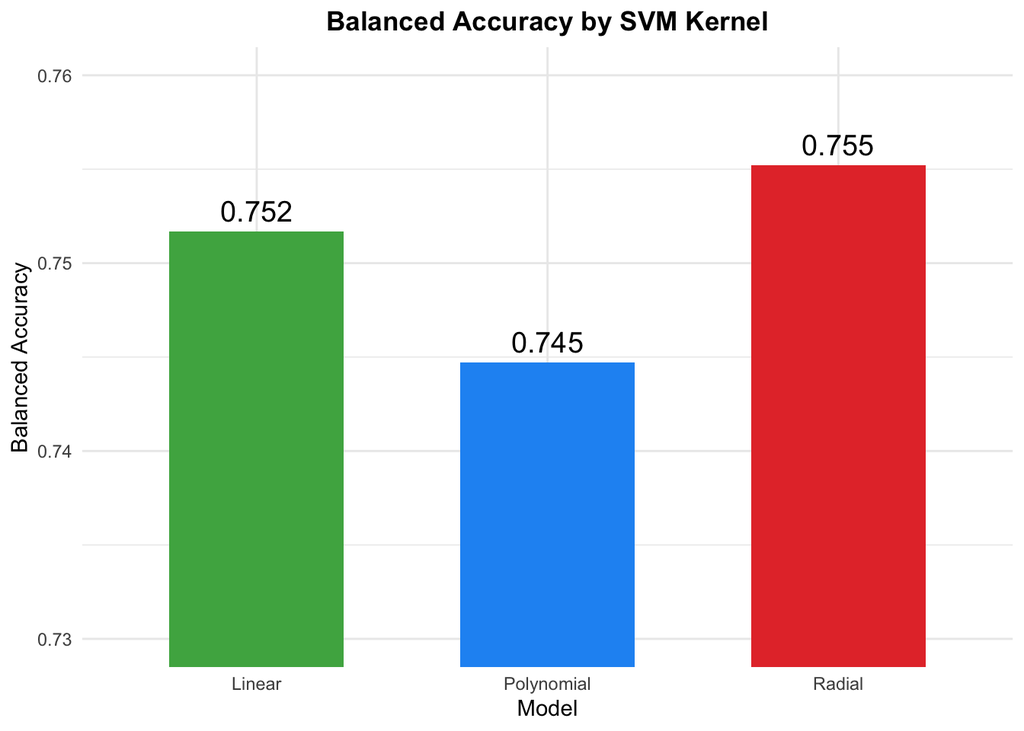

```r
ggplot(model_table, aes(x = Model, y = Balanced_Accuracy, fill = Model)) +
  geom_col(width = 0.6) +
  geom_text(aes(label = round(Balanced_Accuracy, 3)),
            vjust = -0.5, size = 5) +
  coord_cartesian(ylim = c(0.73, 0.76)) +  # ✅ zoom without removing bars
  scale_fill_manual(values = c("#4CAF50", "#2196F3", "#E53935")) +
  labs(
    title = "Balanced Accuracy by SVM Kernel",
    x = "Model",
    y = "Balanced Accuracy"
  ) +
  theme_minimal() +
  theme(
    legend.position = "none",
    plot.title = element_text(hjust = 0.5, face = "bold")
  )
```

### BMI by diabetes status

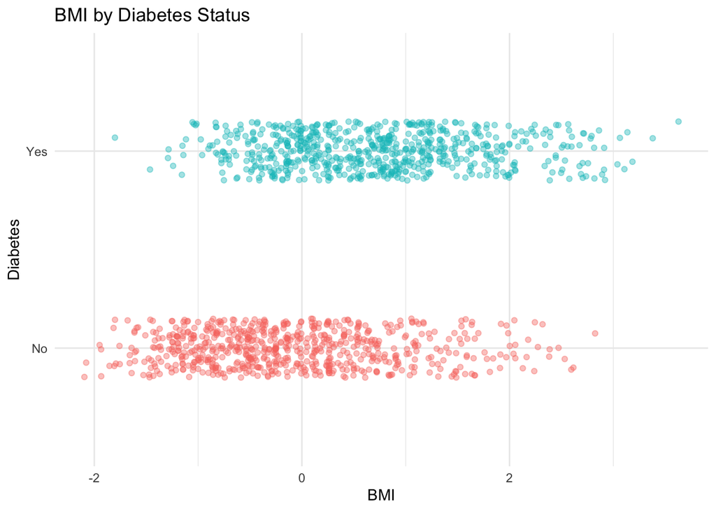

```r
ggplot(train_scaled, aes(x = BMICALC, y = diabetes, color = diabetes)) +
  geom_jitter(height = 0.15, alpha = 0.4) +
  labs(
    title = "BMI by Diabetes Status",
    x = "BMI",
    y = "Diabetes"
  ) +
  theme_minimal() +
  theme(legend.position = "none")
```

## Decision Boundary Plot

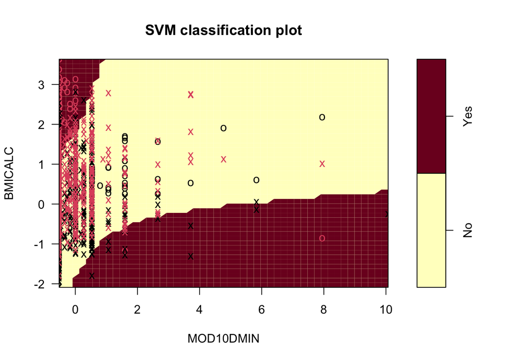

```r
library(e1071)

plot_data <- train_scaled %>%
  select(diabetes, BMICALC, MOD10DMIN)

svm_plot <- svm(
  diabetes ~ .,
  data = plot_data,
  kernel = "polynomial",
  degree = 2,
  cost = 1,
  scale = FALSE
)

plot(svm_plot, plot_data, main = "Polynomial SVM Decision Boundary: BMI vs Moderate Activity")
```